# 1 Séminaire les mesures de l’économie

Printemps 2026

Auteur·rice

Celâl Güney

## 1.1 Présentation du cours

#### 1.1.0.1 Objectif du cours

> > Comprendre et maîtriser les outils indispensables de l’analyse économique

Cela comprend:

- Les variables économiques (PIB, inflation…)
- Les principes de modélisation
- La programmation et l’analyse statistique

## 1.2 Plan du cours

12 séances au total sur 3 thèmes de mesures

1. Comptabilité nationale
2. Inégalités et distribution
3. Institutions

## 1.3 Perspective du cours

Un cours d’analyse appliquée, nous allons beaucoup travailler directement avec des données et des exemples. L’idée est de vous familiariser avec les données économiques, comment les traiter et les analyser.

Après ce cours, vous devriez être capable de mener vos propres analyses quantitatives pour vos recherches et votre PDR.

==> Outils inspensable: R(studio) et Quarto

## 1.4 R & Quarto

En économie, la maîtrise de R est indispensable, car permet:

- Le traitement et la visualisation de données
- La modélisation (régression linéaire, simulation de modèles)
- L’analyse

Quarto est un système de publication qui permet de produire des documents directement à partir de Rstudio (exemple: powerpoints, pdf, sites web…) et donc de code en R.

## 1.5 Évaluation du cours

- Participation au cours (20%)
  - La participation aux séance est obligatoire et sera contrôlée à chaque début de cours
- Examens pratiques (80%)
  - Deux examens: en milieu et fin de semestre
  - Il s’agira de travaux pratiques à réaliser en cours de séance (2h), avec des exercices à réaliser sur R ou excel.

## 1.6 À propos de l’intelligence artificielle

#### 1.6.0.1 *Déconseillé* dans le cadre de ce cours, pour les raisons suivantes:

- Vous n’aurez pas accès aux IA lors des examens pratiques
- Si les IA sont désormais excellentes en programmation (Python, Stata…), les IA les plus utilisées (notamment Chatgpt) produisent du code R qui n’est souvent pas optimale
- Utilisation acceptable dans certains cas, comme pour simplifier des tâches répétitives
- R est le langage avec le plus de ressources et de documentations en ligne, pas besoin de passer par une IA
- Risque de ne pas assimiler le contenu du cours si vous dépendez entièrement des IA pour résoudre les exercices

**Important**

En dehors des examens en présence, je ne peux pas vous interdire l’utilisation des IA. Je vous déconseille l’utilisation de Chatgpt et vous recommande d’utiliser Copilot, dont vous avez une version gratuite avec votre compte Unige. D’autres IA sont meilleures pour R, comme ShinyAssistant.

## 1.7 Apprendre l’analyse à travers R

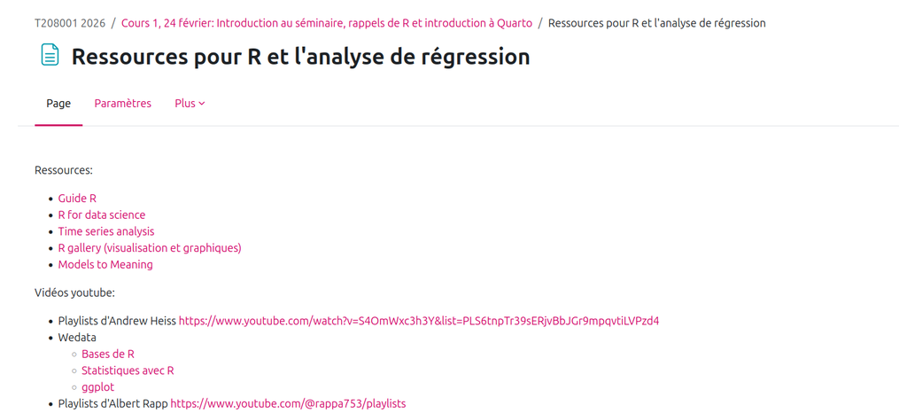

[output not shown]